# So, just how useless is the U.S. Congress?

### Congressional Productivity

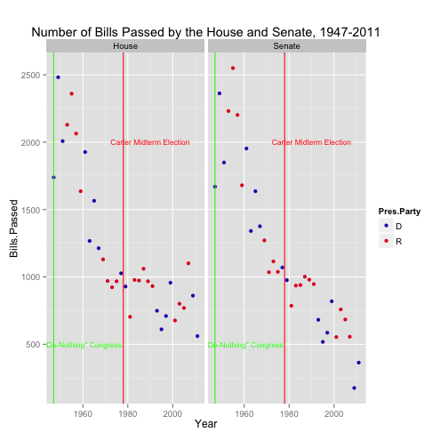

### Congressional Productivity, cont.

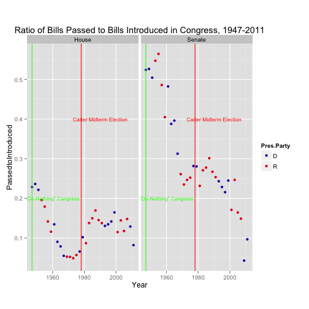

### Congressional Productivity, cont.

- Congressional productivity has almost continually decreased since 1949.
- The infamous 'Do-Nothing' congress (the 80th, from 1947-48) is shockingly productive compared to the most recent congress in the data (the 112th, from 2011-12)

### Does Ideology Affect Productivity?

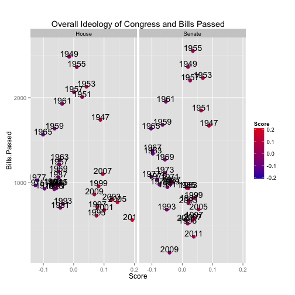

### Does Ideology Affect Productivity? cont.

[figure not shown]

### Does Ideology Affect Productivity? cont.

The overall ideology of the Congress does not seem to have a strong or obvious effect on either number of bills passed or on ratio of bill passed to bills introduced.

But, what about the ideological differences between the parties?

### Does Ideology Affect Productivity? cont.

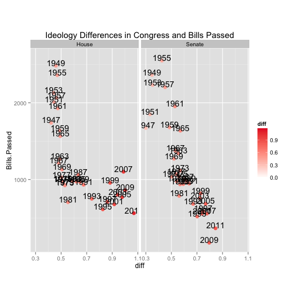

### Does Ideology Affect Productivity? cont.

There is definitely evidence to suggest that as the two parties in congress develop more extreme ideologies, congressional productivity decreases dramatically. There is also evidence to suggest that the increased polarization is in large part due to the drastic increase of conservative ideology amongst congressional Republicans since 1978. The congressional Democrats has also become slightly more liberal since that time, but their change is nowhere near as radical as the republicans'.

### Just a reminder...

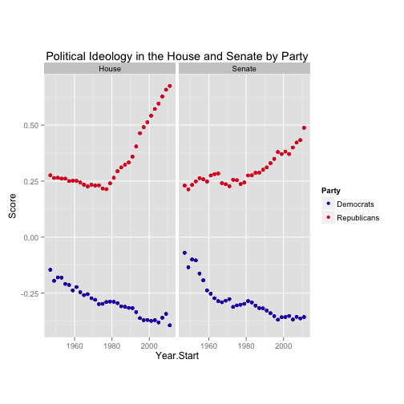

### 2014 Midterm Elections

So, what does this mean for the elections coming up in November of this year?

- We cannot afford to elect more and more extreme candidates to congress. The legislative branch could become completely stalled!
- Cannot let ourselves get sucked into the polarization of American political parties like we have been for the last 30+ years.

### Polarization of Voters

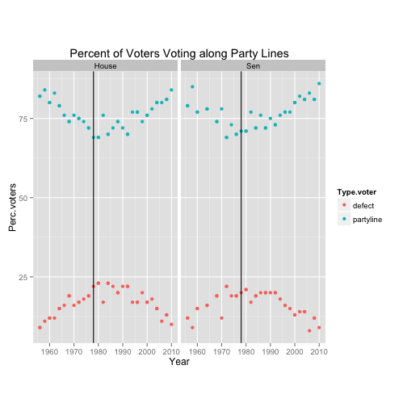

### 2014 Candidates

Will the polarization continue in the 2014 election?

- Look at parties of current candidates
- Compare to parties of incumbents
- See [Party Abbreviations](http://www.fec.gov/finance/disclosure/metadata/DataDictionaryPartyCodeDescriptions.shtml) for help decoding the party labels on the next slides

### 2014 Candidates, cont

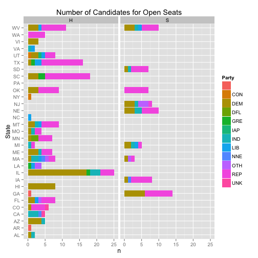

### 2014 Candidates, cont.

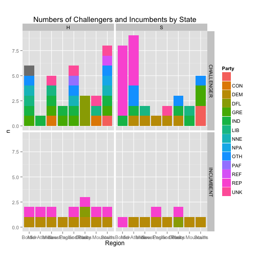

### 2014 Candidates, cont.

- Based on the amount of pink (Republican candidates) in the previous two plots, it looks like the Democrats will have a hard time holding onto their majority in the senate.
- If the Republicans have the majority in both the House and the Senate in 2015 (they currently have the majority in the House), congressional productivity will likely increase due to party unity.
- But with a Democratic president in his last 2 years, there will also probably be a lot of vetoes, so fewer bills are likely to become law. Support of this claim follows.

### Vetoes

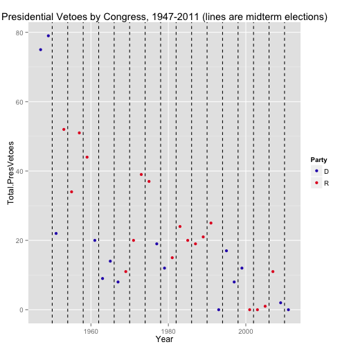

### Conclusion

I might be letting my personal bias affect my conclusions a little bit, but it really seems that the increased polarization in two-party system is destroying the effectiveness of the United States Congress. To solve this problem, Americans have to have some sort of mass crisis of conscience and come together to fix it (not likely), **or** we need to get rid of the two-party system (also not likely), **or** we dropkick the entire U.S. Congress (just kidding).

Basically, the system is broken, and we have to figure out how to fix it. The best thing we can do about this is learn about the candidates in our district and state and **VOTE** in the midterm election in November. Maybe if we as citizens stop picking the most vitriolic candidates, we will actually have a government that governs someday.

### Conclusion, cont.

So, just how useless is the U.S. Congress?

As it turns out, pretty darn useless.

[figure not shown]